# Re-Incarceration

# Building a multi-level models

```python
from sklearn.preprocessing import LabelEncoder
import statsmodels.api as sm
import statsmodels.formula.api as smf


features = ['age', 'sex', 'race','eyeColor', 'hairColor', 'height', 'weight', 'bond', 'bail',
            'topcharge', 'firstappearance', 'county', 'date', 'incarcerated_days',
            'Population', 'Asian Pop', 'Black Pop', 'Hispanic Pop', 'White Pop','Native Pop',
            'Multi-Race Pop', 'Other Pop',
            'Avg Hsld Size','Avg Fam Size', 'Owned Housing', 'Rented Housing',
            'Health Cov','No Health Cov',
            'Med Monthly Housing',
            'Poverty %', 'Male Poverty %','Female Poverty %', 'White Poverty %', 'Black Poverty %',
            'Native Poverty %', 'Asian Poverty %', 'Other Poverty %','Hispanic Poverty %',
            'Multi-Race Poverty %',
            'Black Unemp %','Native Unemp %', 'Asian Unemp %', 'Other Unemp %','Multi-Race Unemp %',
            'Hispanic Unemp %', 'White Unemp %','Male Unemp %', 'Female Unemp %', 'LTHS Unemp %',
            'HS Unemp %','SC/AD Unemp %', 'Bach./Higher Unemp %',
            'Top Political', 'reincarceration']

            #'time_gap','reincarceration', 'incarcerated_counts']

selected_features = df[features].copy()
# Replace spaces and special characters with underscores in column names
selected_features.columns = selected_features.columns.str.replace(' ', '_').str.replace('%', 'pct').str.replace('.', '').str.replace('-', '_').str.replace('/','_')

#replace nan value in bond and bail with 0
selected_features.loc[:,'bond'].fillna(0, inplace = True)
selected_features.loc[:,'age'].fillna(selected_features['age'].mean(), inplace = True)
selected_features.loc[:,'bail'].fillna(0, inplace = True)

# Convert 'firstappearance' to the year as an integer
selected_features.loc[:,'firstappearance'] = selected_features['firstappearance'].dt.year
selected_features.loc[:,'firstappearance'] = selected_features['firstappearance'].astype(int)
selected_features.loc[:,'date'] = selected_features['date'].dt.year
selected_features.loc[:,'date'] = selected_features['date'].astype(int)

# Convert 'sex' and 'topcharge' to categorical columns
selected_features['sex'] = selected_features['sex'].astype('int')
selected_features['eyeColor'] = selected_features['eyeColor'].astype('int')
selected_features['hairColor'] = selected_features['hairColor'].astype('int')
selected_features['race'] = selected_features['race'].astype('int')
selected_features['topcharge'] = selected_features['topcharge'].astype('int')

# Create a LabelEncoder instance
label_encoder = LabelEncoder()
# Assuming 'county' is a column in your DataFrame 'df'
selected_features['county'] = label_encoder.fit_transform(selected_features['county'])
selected_features['Top_Political'] = label_encoder.fit_transform(selected_features['Top_Political'])

import statsmodels.api as sm
import statsmodels.formula.api as smf

# Create a formula for the model excluding the 'reincarceration' column
formula = 'reincarceration ~ ' + ' + '.join(selected_features.columns.difference(['reincarceration'])) + ' + (1 | county)'

# Fit the mixed-effects model
mixed_model = smf.mixedlm(formula, data=selected_features, groups=selected_features['county'])
result = mixed_model.fit()

# Print the summary
print(result.summary())
```

```
                      Mixed Linear Model Regression Results
=================================================================================
Model:                    MixedLM       Dependent Variable:       reincarceration
No. Observations:         601261        Method:                   REML
No. Groups:               35            Scale:                    0.2384
Min. group size:          500           Log-Likelihood:           -422395.0613
Max. group size:          116388        Converged:                Yes
Mean group size:          17178.9
---------------------------------------------------------------------------------
                         Coef.     Std.Err.     z    P>|z|    [0.025     0.975]
---------------------------------------------------------------------------------
Intercept              191798.942
Asian_Pop                -381.635  11337.447  -0.034 0.973  -22602.622  21839.352
Asian_Poverty_pct         732.114   5347.325   0.137 0.891   -9748.450  11212.678
Asian_Unemp_pct          -143.186  10356.974  -0.014 0.989  -20442.481  20156.110
Avg_Fam_Size            -2019.396
Avg_Hsld_Size          -13058.651 497542.494  -0.026 0.979 -988224.019 962106.718
Bach_Higher_Unemp_pct   -4866.904
Black_Pop               -1910.910
Black_Poverty_pct         -24.502  12420.042  -0.002 0.998  -24367.337  24318.333
Black_Unemp_pct          -356.711
Female_Poverty_pct      -8937.845
Female_Unemp_pct         6141.345
HS_Unemp_pct            -1507.710
Health_Cov               -668.822  12894.920  -0.052 0.959  -25942.401  24604.758
Hispanic_Pop             -412.175  50557.490  -0.008 0.993  -99503.034  98678.683
Hispanic_Poverty_pct     1784.443
Hispanic_Unemp_pct      -2297.629
LTHS_Unemp_pct            678.969   8396.348   0.081 0.936  -15777.571  17135.509
Male_Poverty_pct         4969.317
Male_Unemp_pct           3536.293
Med_Monthly_Housing        -1.372
Multi_Race_Pop           3953.860 132660.028   0.030 0.976 -256055.017 263962.738
Multi_Race_Poverty_pct  -1458.657
Multi_Race_Unemp_pct     2708.739
Native_Pop              -4485.749  67767.402  -0.066 0.947 -137307.417 128335.918
Native_Poverty_pct        604.139
Native_Unemp_pct         -824.116
No_Health_Cov            1481.437
Other_Pop               14616.927 154213.167   0.095 0.924 -287635.326 316869.180
```

[output cut: 13 more lines]

```
bond                       -0.000      0.000  -7.277 0.000      -0.000     -0.000
county                  -3058.904
date                        0.008      0.003   2.487 0.013       0.002      0.014
eyeColor                   -0.003      0.001  -4.153 0.000      -0.004     -0.001
firstappearance            -0.005      0.003  -1.772 0.076      -0.011      0.001
hairColor                  -0.006      0.001  -9.038 0.000      -0.007     -0.005
height                      0.006      0.000  22.991 0.000       0.005      0.006
incarcerated_days          -0.000      0.000 -13.541 0.000      -0.000     -0.000
race                       -0.008      0.001 -14.803 0.000      -0.009     -0.007
sex                         0.009      0.001  15.040 0.000       0.008      0.010
topcharge                  -0.018      0.000 -49.299 0.000      -0.019     -0.017
weight                     -0.000      0.000  -0.108 0.914      -0.000      0.000
1 | county               2313.206   6580.566   0.352 0.725  -10584.466  15210.877
Group Var                   0.238
=================================================================================
```

```python
# Adjust the significance level as needed
significance_level = 0.05

# Extract coefficients and p-values from the model summary
coefficients = result.params
p_values = result.pvalues

# Create a DataFrame with coefficients and p-values
coefficients_df = pd.DataFrame({'Coefficient': coefficients, 'P-Value': p_values})

# Filter significant predictors based on the significance level
significant_predictors = coefficients_df[coefficients_df['P-Value'] < significance_level]

# Display the significant predictors
print("Significant Predictors:")
print(significant_predictors)
```

```
Significant Predictors:
                    Coefficient        P-Value
age               -1.045992e-03   2.245878e-72
bail              -8.597777e-09   1.291324e-03
bond              -2.634092e-09   3.425624e-13
date               7.651860e-03   1.289047e-02
eyeColor          -2.794734e-03   3.282804e-05
hairColor         -5.969262e-03   1.588865e-19
height             5.812881e-03  5.744870e-117
incarcerated_days -1.326611e-04   9.016379e-42
race              -8.056049e-03   1.405470e-49
sex                9.061194e-03   3.986501e-51
topcharge         -1.813128e-02   0.000000e+00
```

```python
import statsmodels.api as sm
import pandas as pd
from scipy.stats import chi2

# Assuming 'result' is the variable containing the mixed-effects model result

# Create a formula for the model excluding the 'reincarceration' column
original_formula = 'reincarceration ~ ' + ' + '.join(selected_features.columns.difference(['reincarceration'])) + ' + (1 | county)'
original_model = smf.mixedlm(original_formula, data=selected_features, groups=selected_features['county'])
original_result = original_model.fit()

# Fit a null model (intercept-only model)
null_formula = 'reincarceration ~ 1'  # 1 indicates an intercept-only model
null_model = smf.mixedlm(null_formula, data=selected_features, groups=selected_features['county'])
null_result = null_model.fit()


# Get log-likelihood values for the current and null models
log_likelihood_current = original_result.llf
log_likelihood_null = null_result.llf

# Compute the number of parameters for each model
num_params_current = original_result.df_modelwc
num_params_null = null_result.df_modelwc

# Perform a likelihood ratio test
likelihood_ratio_test = -2 * (log_likelihood_null - log_likelihood_current)
degrees_of_freedom = num_params_current - num_params_null

# Avoid negative degrees of freedom
degrees_of_freedom = max(0, degrees_of_freedom)

# Calculate the p-value
p_value = 1.0 - chi2.cdf(likelihood_ratio_test, degrees_of_freedom)

# Display results
print(f"Likelihood Ratio Test: {likelihood_ratio_test}")
print(f"Degrees of Freedom: {degrees_of_freedom}")
print(f"P-Value: {p_value}")
```

```
Likelihood Ratio Test: 4732.824321529828
Degrees of Freedom: 54
P-Value: 0.0
```

#### Interpretation:

- Likelihood Ratio Test Statistic (4732.82):
  - This value represents the measure of the difference in fit between the full model (your model with predictors and random effects) and the null model (intercept-only model). Larger values indicate a greater difference in fit.
- Degrees of Freedom (54):
  - Degrees of freedom represent the number of additional parameters in the full model compared to the null model. In this case, the difference in the number of parameters is 54.
- P-Value (0.0):
  - The p-value associated with the likelihood ratio test is extremely small (close to zero). This suggests strong evidence against the null hypothesis, indicating that the full model with predictors and random effects fits the data significantly better than the null model.

#### Conclusion:

The small p-value indicates that the inclusion of predictors and random effects in your model has significantly improved its fit compared to an intercept-only model. Therefore, you have evidence to reject the null hypothesis that the simpler model (null model) is sufficient. The full model, which includes the specified predictors and random effects, provides a better explanation of the variability in the response variable. In summary, your model appears to be statistically significant and provides a better fit to the data than a model with no predictors.

# Machine Learning Models for Feature Importances

```python
not_selected = ['nameFull', 'bookingNumber', 'bookingDate', 'caseNumber',
                'inmateNumber', 'housing1', 'housing1a', 'housing2', 'housing3',
                'nameLast', 'nameFirst', 'nameMiddle', 'dob' ,
                'time_gap', 'incarcerated_counts', 'reincarcerations_different_county']

# Convert date-related columns to datetime
date_columns = ['firstappearance', 'date']
for col in date_columns:
    df.loc[:,col] = pd.to_datetime(df[col], errors='coerce')

#replace nan value in bond and bail with 0
df.loc[:,'bond'].fillna(0, inplace = True)
df.loc[:,'age'].fillna(df['age'].mean(), inplace = True)
df.loc[:,'bail'].fillna(0, inplace = True)

# Convert 'firstappearance' to the year as an integer
df.loc[:,'firstappearance'] = df['firstappearance'].dt.year
df.loc[:,'firstappearance'] = df['firstappearance'].astype(int)
df.loc[:,'date'] = df['date'].dt.year
df.loc[:,'date'] = df['date'].astype(int)


# Convert 'sex' and 'topcharge' to categorical columns
df['sex'] = df['sex'].astype('category')
df['eyeColor'] = df['eyeColor'].astype('category')
df['hairColor'] = df['hairColor'].astype('category')
df['race'] = df['race'].astype('category')
df['county'] = df['county'].astype('category')
#df = pd.get_dummies(df, columns=['county'], drop_first=True)
df['topcharge'] = df['topcharge'].astype('category')
df['Top Political'] = df['Top Political'].astype('category')
#df = pd.get_dummies(df, columns=['Top Political'], drop_first=True)
```

```python
#Choose all predictors except target & IDcols
#predictors = df[features]
rcParams['figure.figsize'] = 12, 4

def modelfit(alg, dtrain, predictors, dtest ,useTrainCV=True, cv_folds=5, early_stopping_rounds=50):

    if useTrainCV:
        xgb_param = alg.get_xgb_params()
        #xgtrain = xgb.DMatrix(dtrain[predictors].values,
                              #label=dtrain['reincarceration'].values,
                              #enable_categorical = True)
        cvresult = xgb.cv(xgb_param, dtrain,
                          num_boost_round=alg.get_params()['n_estimators'],
                          nfold=cv_folds,
                          metrics='auc',
                          early_stopping_rounds=early_stopping_rounds,
                         verbose_eval = 50)

        alg.set_params(n_estimators=cvresult.shape[0])

    #Fit the algorithm on the data
    alg.fit(dtrain.get_data(), dtrain.get_label() ,eval_metric='auc')

    #Predict training set:
    dtrain_predictions = alg.predict(dtrain.get_data())
    dtrain_predprob = alg.predict_proba(dtrain.get_data())[:,1]

    # Predict test set
    dtest_predictions = alg.predict(dtest.get_data())
    dtest_predprob = alg.predict_proba(dtest.get_data())[:, 1]

    #Print model report:
    print ("\nModel Report")
    print ("Accuracy : %.4g" % metrics.accuracy_score(dtest.get_label(), dtest_predictions))
    print ("AUC Score (Train): %f" % metrics.roc_auc_score(dtrain.get_label(), dtrain_predprob))
    print ("AUC Score (Test): %f" % metrics.roc_auc_score(dtest.get_label(), dtest_predprob))


    feat_imp = pd.Series(alg.get_booster().get_fscore()).sort_values(ascending=False)
    feature_mapping = {f"f{idx}": name for idx, name in enumerate(X)}

    # Print feature importance scores
    print("Feature Importance Scores:")
    for feature, score in feat_imp.items():
        original_feature_name = feature_mapping.get(feature, "Unknown")
        print(f"{original_feature_name if original_feature_name != 'Unknown' else feature}: {score}")

    # Sort feature importances in descending order
    feat_imp = feat_imp.sort_values(ascending=False)

    # Get the feature names based on their index using the feature_mapping dictionary
    feature_names = [feature_mapping.get(feature, f"f{feature}") for feature in feat_imp.index]

    # Plot the feature importances with feature names
    feat_imp.plot(kind='bar', title='Feature Importances')
    plt.xticks(range(len(feature_names)), feature_names, rotation=90)  # Set x-axis labels
    plt.ylabel('Feature Importance Score')
```

[output not shown]

[figure not shown]

```python
predictors = [x for x in df.columns if x not in not_selected]
X = df[predictors]
y = df['reincarceration']

# Split the data into training and testing sets
X_train, X_test, y_train, y_test = train_test_split(X, y, test_size=0.2, random_state=42)


# Create a DMatrix with enable_categorical=True
dtrain = xgb.DMatrix(X_train, label = y_train, enable_categorical=True)
dtest = xgb.DMatrix(X_test, label = y_test, enable_categorical=True)

xgb1 = XGBClassifier(learning_rate =0.1,
 n_estimators=895,
 max_depth=5,
 min_child_weight=5,
 gamma=0.3,
 subsample=0.8,
 colsample_bytree=0.8,
 objective= 'binary:logistic',
 nthread=4,
 scale_pos_weight=1,
 seed=27,
 enable_categorical = True)

modelfit(xgb1, dtrain, predictors, dtest = dtest)
```

### Common strong predictors:

- age
- incarcerated_days
- bond/bail
- race
- topcharge
- weight
- height
- county
- Population (Asian Pop, White Pop, Black Pop etc.)
- Poverty %
- Unemployment %

### Differences in strong predictors:

- Linear and Lasso Regression: Includes features like 'age', 'bond', 'bail', 'county', 'Population', 'White Pop', 'Med Monthly Housing',
- XGBoost: Puts more emphasis on features like age, incarcerated_days, bond, weight, height, topcharge, race, bail, sex, county, population and unemployment %

It seems that while some features are common strong predictors, there are differences in the emphasis placed on certain features by the linear and Lasso regression compared to XGBoost models. The choice of strong predictors can be influenced by the modeling technique and the inherent characteristics of the data. Linear and Lasso regression focuses on coefficients and their statistical significance, while XGBoost considers the importance of features based on their contribution to the model's predictive performance (the ability of variables in making better prediction)

Note that: The importance score of a feature in XGBoost reflects its contribution to the model's predictive performance. A low score doesn't necessarily mean it's a weak predictor; it might indicate that the feature doesn't play a crucial role in the specific context of the model or that its contribution is overshadowed by other more influential features.

```
Model Report
Accuracy : 0.8516
AUC Score (Train): 0.700899
AUC Score (Test): 0.663339
Feature Importance Scores:
age: 3113.0
incarcerated_days: 2254.0
weight: 2072.0
height: 1711.0
bond: 1638.0
race: 771.0
bail: 731.0
topcharge: 712.0
hairColor: 548.0
eyeColor: 496.0
sex: 276.0
county: 252.0
Population: 222.0
Black Pop: 217.0
Black Unemp %: 180.0
Asian Pop: 166.0
Black Poverty %: 154.0
Asian Poverty %: 145.0
Native Pop: 143.0
Native Poverty %: 138.0
Other Pop: 138.0
Health Cov: 137.0
Multi-Race Pop: 134.0
Owned Housing: 126.0
Avg Hsld Size: 125.0
Bach./Higher Unemp %: 118.0
Other Poverty %: 118.0
Multi-Race Unemp %: 117.0
Native Unemp %: 115.0
Other Unemp %: 114.0
Hispanic Pop: 114.0
White Pop: 112.0
Asian Unemp %: 110.0
Med Monthly Housing: 99.0
SC/AD Unemp %: 95.0
White Unemp %: 79.0
Multi-Race Poverty %: 78.0
Avg Fam Size: 73.0
White Poverty %: 73.0
Hispanic Poverty %: 71.0
Hispanic Unemp %: 69.0
HS Unemp %: 65.0
LTHS Unemp %: 62.0
Female Unemp %: 60.0
Male Unemp %: 57.0
Poverty %: 51.0
Female Poverty %: 39.0
Male Poverty %: 34.0
No Health Cov: 30.0
Top Political: 23.0
Rented Housing: 18.0
```

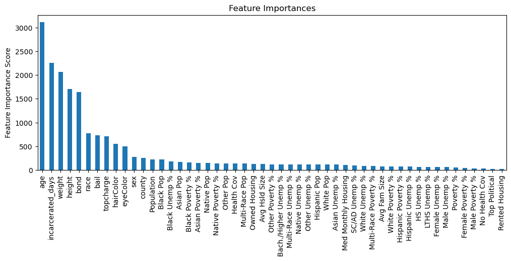

```python
predictors = [x for x in df.columns if x not in not_selected]
X = df[predictors]
y = df['reincarcerations_different_county']

# Split the data into training and testing sets
X_train, X_test, y_train, y_test = train_test_split(X, y, test_size=0.2, random_state=42)


# Create a DMatrix with enable_categorical=True
dtrain = xgb.DMatrix(X_train, label = y_train, enable_categorical=True)
dtest = xgb.DMatrix(X_test, label = y_test, enable_categorical=True)

xgb1 = XGBClassifier(learning_rate =0.1,
 n_estimators=895,
 max_depth=5,
 min_child_weight=5,
 gamma=0.3,
 subsample=0.8,
 colsample_bytree=0.8,
 objective= 'binary:logistic',
 nthread=4,
 scale_pos_weight=1,
 seed=27,
 enable_categorical = True)

modelfit(xgb1, dtrain, predictors, dtest = dtest)
```

#### Interpretation

- Model Performance Metrics:
  - Accuracy: 0.8516
    - This represents the overall correctness of the model's predictions on the test set. In this case, around 85.16% of the predictions are correct.
  - AUC Score (Train): 0.700899
    - The AUC (Area Under the Curve) score for the training set measures the model's ability to distinguish between positive and negative instances. A score of 0.7 is reasonably good, suggesting that the model performs better than random chance on the training data.
  - AUC Score (Test): 0.663339
    - The AUC score for the test set is slightly lower than the training AUC. This metric evaluates the model's generalization to new, unseen data. While 0.66 is not a very high AUC score, it still indicates some ability to discriminate between classes.
- Feature Importance Scores: These scores represent the importance of each feature in the model. Higher scores indicate more influential features in making predictions.
  - Top Features:
    - age: 3113.0
    - incarcerated_days: 2254.0
    - weight: 2072.0
    - height: 1711.0
    - bond: 1638.0
- Interpretation:
  - Features with higher importance scores contribute more to the model's decision-making process.
  - In this specific case, features related to age, days incarcerated, weight, height, and bond amount seem to have the highest impact on the model's predictions.
- Recommendations:
  - Consider further analyzing and understanding the context of these top features to gain insights into why they are influential.
  - If necessary, domain knowledge can be used to interpret the findings and potentially improve the model or refine the features.
- Next Steps:
  - Depending on the specific requirements and domain knowledge, you might want to experiment with model hyperparameters or feature engineering to improve the model's performance.
  - If the model's predictive performance is critical, you may also consider fine-tuning hyperparameters or exploring other algorithms.
  - Remember, while accuracy and AUC are essential metrics, the context of your specific problem and the consequences of false positives/negatives should guide your interpretation and decision-making.

# Choose better predictors to build ML models using XGBoost

```
Model Report
Accuracy : 0.8921
AUC Score (Train): 0.910417
AUC Score (Test): 0.898597
Feature Importance Scores:
age: 3012.0
incarcerated_counts: 2654.0
incarcerated_days: 2366.0
weight: 2053.0
bond: 1569.0
height: 1567.0
county: 1155.0
Population: 1121.0
race: 930.0
Poverty %: 900.0
Health Cov: 884.0
topcharge: 839.0
bail: 727.0
hairColor: 617.0
eyeColor: 521.0
sex: 412.0
```

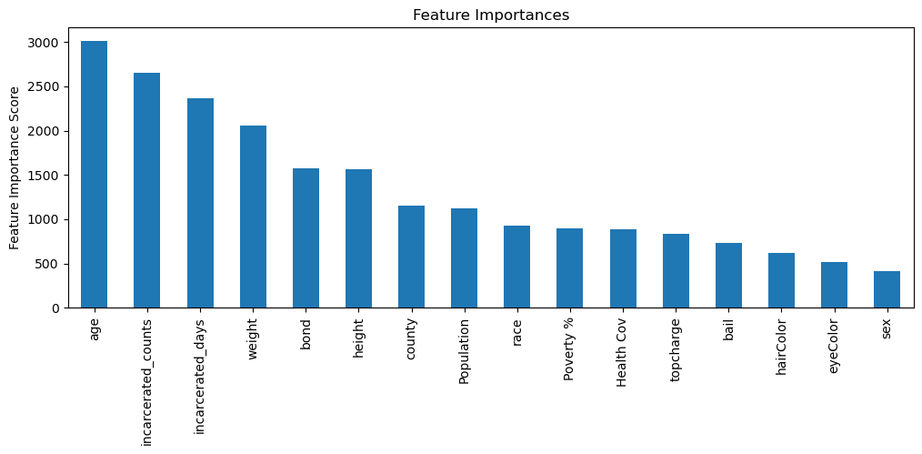

```python
predictors = ['age', 'incarcerated_days', 'bond', 'weight', 'height', 'bail', 'race', 'topcharge',
             'hairColor', 'eyeColor', 'sex', 'county', 'Population', 'Poverty %', 'Health Cov',
             'incarcerated_counts']
X = df[predictors]
y = df['reincarcerations_different_county']

# Split the data into training and testing sets
X_train, X_test, y_train, y_test = train_test_split(X, y, test_size=0.2, random_state=42)


# Create a DMatrix with enable_categorical=True
dtrain = xgb.DMatrix(X_train, label = y_train, enable_categorical=True)
dtest = xgb.DMatrix(X_test, label = y_test, enable_categorical=True)

xgb1 = XGBClassifier(learning_rate =0.1,
 n_estimators=895,
 max_depth=5,
 min_child_weight=5,
 gamma=0.3,
 subsample=0.8,
 colsample_bytree=0.8,
 objective= 'binary:logistic',
 nthread=4,
 scale_pos_weight=1,
 seed=27,
 enable_categorical = True)

modelfit(xgb1, dtrain, predictors, dtest = dtest)
```

#### Interpretation:

- Accuracy: 0.8921
  - This represents the overall correctness of the model's predictions on the test set. In this case, around 89.21% of the predictions are correct.
- AUC Score (Train): 0.910417
  - The AUC (Area Under the Curve) score for the training set is high (0.91), indicating that the model performs well in distinguishing between positive and negative instances on the training data.
- AUC Score (Test): 0.898597
  - The AUC score for the test set is also high (0.8986), indicating good generalization to new, unseen data.
- Feature Importance Scores:These scores represent the importance of each feature in the model. Higher scores indicate more influential features in making predictions.
  - Top Features:
    - age: 3012.0
    - incarcerated_counts: 2654.0
    - incarcerated_days: 2366.0
    - weight: 2053.0
    - bond: 1569.0
- Interpretation:
  - Features with higher importance scores contribute more to the model's decision-making process.
  - In this specific case, features related to age, the count and days of incarceration, weight, and bond amount seem to have the highest impact on the model's predictions.
- Recommendations:
  - Consider further analyzing and understanding the context of these top features to gain insights into why they are influential.
  - If necessary, domain knowledge can be used to interpret the findings and potentially improve the model or refine the features.
- Next Steps:
  - Given the high AUC scores and accuracy, the model seems to be performing well on both the training and test sets.
    - Consider monitoring the model's performance over time and checking if the results hold on new data.
    - If applicable, explore opportunities for model deployment in real-world scenarios.

# Neural Network Model

#### Neural Network Model:

```python
import keras.backend as K

# Clear session
K.clear_session()
```

```python
import numpy as np
import pandas as pd
from sklearn.model_selection import train_test_split
from sklearn.preprocessing import StandardScaler
from sklearn.metrics import accuracy_score, roc_auc_score
import tensorflow as tf
from tensorflow.keras.models import Sequential
from tensorflow.keras.layers import Dense
from sklearn.preprocessing import LabelEncoder
from tensorflow.keras.layers import Dense, Dropout
from tensorflow.keras.optimizers import Adam
from tensorflow.keras.initializers import GlorotNormal
from tensorflow.keras.callbacks import EarlyStopping

# Assuming your data is in a DataFrame named 'df'
# Features
X = df[['age', 'incarcerated_days', 'weight', 'height', 'bond', 'race', 'bail', 'topcharge',
        'hairColor', 'eyeColor', 'sex', 'county', 'Population', 'Black Pop', 'Black Unemp %',
        'Asian Pop', 'Black Poverty %', 'Asian Poverty %', 'Native Pop', 'Native Poverty %',
        'Other Pop', 'Health Cov', 'Multi-Race Pop', 'Owned Housing', 'Avg Hsld Size',
        'Bach./Higher Unemp %', 'Other Poverty %', 'Multi-Race Unemp %', 'Native Unemp %',
        'Other Unemp %', 'Hispanic Pop', 'White Pop', 'Asian Unemp %', 'Med Monthly Housing',
        'SC/AD Unemp %', 'White Unemp %', 'Multi-Race Poverty %', 'Avg Fam Size',
        'White Poverty %', 'Hispanic Poverty %', 'Hispanic Unemp %', 'HS Unemp %',
        'LTHS Unemp %', 'Female Unemp %', 'Male Unemp %', 'Poverty %', 'Female Poverty %',
        'Male Poverty %', 'No Health Cov', 'Top Political', 'Rented Housing']]
#replace nan value in bond and bail with 0
X['bond'].fillna(0, inplace = True)
X['age'].fillna(df['age'].mean(), inplace = True)
X['bail'].fillna(0, inplace = True)

# Convert 'firstappearance' to the year as an integer
#X.loc[:,'firstappearance'] = X['firstappearance'].dt.year
#X.loc[:,'firstappearance'] = X['firstappearance'].astype(int)
#X.loc[:,'date'] = X['date'].dt.year
#X.loc[:,'date'] = X['date'].astype(int)

# Convert 'sex' and 'topcharge' to categorical columns
X.loc[:,'sex'] = X['sex'].astype('category')
X.loc[:,'eyeColor'] = X['eyeColor'].astype('category')
X.loc[:,'hairColor'] = X['hairColor'].astype('category')
X.loc[:,'race'] = X['race'].astype('category')

# Initialize a label encoder
label_encoder = LabelEncoder()
# Assuming 'county' is a column in your DataFrame 'df'
X.loc[:,'county'] = label_encoder.fit_transform(X['county'])
X.loc[:,'Top Political'] = label_encoder.fit_transform(X['Top Political'])

# Target variable
y = df['reincarcerations_different_county']  # Replace 'target_variable' with the actual column name you're predicting

# Split the data into training and testing sets
X_train, X_test, y_train, y_test = train_test_split(X, y, test_size=0.2, random_state=42)

# Standardize the features
scaler = StandardScaler()
X_train = scaler.fit_transform(X_train)
X_test = scaler.transform(X_test)

model = Sequential()
model.add(Dense(64, activation='relu',kernel_initializer=GlorotNormal(), input_dim=X_train.shape[1]))
model.add(Dropout(0.5)) #add dropout layer to prevent overfitting
model.add(Dense(32, activation='relu'))
model.add(Dense(1, activation='sigmoid'))

optimizer = Adam(learning_rate=0.0001) #set up low learning rate to prevent over-fitting
model.compile(optimizer=optimizer, loss='binary_crossentropy', metrics=['accuracy'])

# Train the model
early_stopping = EarlyStopping(monitor='val_loss', patience=5, restore_best_weights=True)
model.fit(X_train, y_train, epochs=50, batch_size=16, validation_data=(X_test, y_test), verbose=2)

# Evaluate the model
y_pred = model.predict(X_test)
y_pred_binary = (y_pred > 0.5).astype(int)

accuracy = accuracy_score(y_test, y_pred_binary)
auc_score = roc_auc_score(y_test, y_pred)

print(f'Accuracy: {accuracy:.4f}')
print(f'AUC Score: {auc_score:.4f}')
```

```
2023-11-09 17:27:45.066265: E tensorflow/core/grappler/optimizers/meta_optimizer.cc:961] model_pruner failed: INVALID_ARGUMENT: Graph does not contain terminal node Adam/AssignAddVariableOp.
```

[output not shown]

# Time Series Analysis

The provided input code prepares the data for time series forecasting. As the original DataFrame df contains columns including 'date', 'county', and 'reincarceration', the code first sets the 'date' column as the index. Subsequently, it resamples the data to a monthly frequency and sums the counts for each county within each month. The resulting DataFrame, named df_monthly, is then pivoted to transform counties into columns and months into rows. This pivot operation creates a new DataFrame, df_pivot, which is displayed to provide an overview of the reshaped data structure. The resulting df_pivot is utilized in the subsequent time series forecasting code to predict future reincarceration counts for each county.

```python
import pandas as pd

# Assuming df is your original DataFrame containing the data
# Make sure 'date' is already in datetime format

# Set 'date' as the index
df.set_index('date', inplace=True)

# Resample data to monthly frequency and sum the counts for each county
df_monthly = df.groupby(['county', pd.Grouper(freq='M')])['reincarceration'].sum().reset_index()

# Pivot the DataFrame to have counties as columns and months as rows
df_pivot = df_monthly.pivot(index='date', columns='county', values='reincarceration').fillna(0)

# Display the resulting DataFrame
display(df_pivot)
```

| county date | Monterey | Santa Cruz | Tulare | Madera | Calaveras | San Francisco | Marin | Shasta | Merced | Santa Barbara | ... | Solano | San Luis Obispo | Riverside | Yuba | Fresno | Siskiyou | Mariposa | Nevada | Tehama | Stanislaus |
| --- | --- | --- | --- | --- | --- | --- | --- | --- | --- | --- | --- | --- | --- | --- | --- | --- | --- | --- | --- | --- | --- |
| 2020-01-31 | 0 | 0 | 0 | 0 | 0 | 0 | 0 | 0 | 0 | 120 | ... | 0 | 0 | 0 | 0 | 0 | 0 | 0 | 0 | 0 | 0 |
| 2020-02-29 | 0 | 0 | 390 | 0 | 0 | 0 | 0 | 159 | 0 | 365 | ... | 0 | 0 | 0 | 140 | 0 | 22 | 0 | 0 | 0 | 395 |
| 2020-03-31 | 0 | 0 | 738 | 0 | 0 | 0 | 0 | 188 | 0 | 0 | ... | 0 | 0 | 0 | 127 | 0 | 47 | 0 | 14 | 0 | 566 |
| 2020-04-30 | 0 | 0 | 531 | 0 | 0 | 0 | 36 | 153 | 0 | 0 | ... | 0 | 0 | 0 | 56 | 0 | 37 | 0 | 51 | 20 | 452 |
| 2020-05-31 | 0 | 65 | 487 | 0 | 0 | 0 | 56 | 163 | 0 | 0 | ... | 115 | 0 | 0 | 44 | 281 | 32 | 0 | 43 | 36 | 313 |
| 2020-06-30 | 0 | 89 | 452 | 49 | 0 | 0 | 47 | 194 | 72 | 93 | ... | 190 | 0 | 0 | 41 | 537 | 38 | 0 | 57 | 38 | 377 |
| 2020-07-31 | 203 | 132 | 505 | 94 | 0 | 0 | 50 | 257 | 166 | 243 | ... | 222 | 0 | 0 | 55 | 638 | 35 | 0 | 66 | 33 | 298 |
| 2020-08-31 | 215 | 136 | 587 | 113 | 0 | 0 | 58 | 227 | 143 | 0 | ... | 257 | 0 | 0 | 62 | 593 | 32 | 0 | 77 | 45 | 301 |
| 2020-09-30 | 196 | 129 | 561 | 128 | 0 | 0 | 68 | 195 | 160 | 0 | ... | 288 | 0 | 0 | 103 | 611 | 33 | 0 | 69 | 41 | 345 |
| 2020-10-31 | 186 | 138 | 564 | 153 | 0 | 0 | 94 | 222 | 165 | 0 | ... | 315 | 0 | 0 | 82 | 624 | 36 | 0 | 80 | 54 | 425 |
| 2020-11-30 | 241 | 131 | 501 | 122 | 0 | 0 | 90 | 177 | 192 | 0 | ... | 356 | 0 | 0 | 51 | 692 | 44 | 0 | 84 | 39 | 379 |
| 2020-12-31 | 223 | 133 | 482 | 94 | 0 | 0 | 81 | 194 | 165 | 0 | ... | 156 | 0 | 0 | 62 | 645 | 33 | 0 | 55 | 38 | 353 |
| 2021-01-31 | 179 | 110 | 518 | 82 | 0 | 0 | 73 | 221 | 129 | 0 | ... | 255 | 0 | 0 | 59 | 567 | 29 | 0 | 53 | 55 | 328 |
| 2021-02-28 | 216 | 111 | 501 | 103 | 0 | 0 | 76 | 179 | 181 | 50 | ... | 310 | 0 | 0 | 77 | 329 | 31 | 0 | 50 | 23 | 341 |
| 2021-03-31 | 228 | 133 | 556 | 179 | 0 | 0 | 94 | 258 | 140 | 247 | ... | 331 | 0 | 0 | 60 | 747 | 43 | 0 | 68 | 61 | 449 |
| 2021-04-30 | 239 | 169 | 567 | 145 | 0 | 0 | 103 | 218 | 209 | 187 | ... | 320 | 0 | 584 | 78 | 697 | 38 | 0 | 83 | 53 | 418 |
| 2021-05-31 | 232 | 144 | 570 | 126 | 0 | 0 | 81 | 248 | 162 | 241 | ... | 286 | 0 | 1160 | 70 | 734 | 45 | 0 | 65 | 60 | 503 |
| 2021-06-30 | 229 | 142 | 624 | 171 | 0 | 0 | 85 | 272 | 252 | 219 | ... | 296 | 0 | 1379 | 134 | 748 | 53 | 0 | 67 | 57 | 434 |
| 2021-07-31 | 313 | 160 | 609 | 148 | 0 | 0 | 107 | 237 | 0 | 266 | ... | 286 | 0 | 1299 | 108 | 877 | 54 | 0 | 68 | 40 | 474 |
| 2021-08-31 | 274 | 197 | 633 | 190 | 0 | 0 | 89 | 297 | 0 | 259 | ... | 307 | 0 | 1311 | 74 | 914 | 52 | 0 | 77 | 53 | 450 |
| 2021-09-30 | 297 | 177 | 614 | 141 | 0 | 0 | 117 | 202 | 0 | 250 | ... | 298 | 0 | 1431 | 61 | 851 | 41 | 0 | 73 | 51 | 543 |
| 2021-10-31 | 260 | 163 | 546 | 128 | 0 | 0 | 109 | 193 | 96 | 247 | ... | 274 | 0 | 1409 | 93 | 760 | 44 | 0 | 61 | 44 | 534 |
| 2021-11-30 | 230 | 147 | 539 | 156 | 0 | 0 | 95 | 326 | 185 | 260 | ... | 246 | 0 | 730 | 99 | 782 | 37 | 0 | 71 | 40 | 530 |
| 2021-12-31 | 274 | 150 | 807 | 139 | 7 | 79 | 105 | 0 | 195 | 310 | ... | 267 | 0 | 204 | 95 | 687 | 29 | 8 | 73 | 58 | 520 |
| 2022-01-31 | 241 | 134 | 0 | 80 | 29 | 318 | 99 | 0 | 174 | 229 | ... | 0 | 74 | 1353 | 80 | 655 | 32 | 14 | 56 | 58 | 455 |
| 2022-02-28 | 264 | 166 | 0 | 143 | 30 | 297 | 103 | 0 | 170 | 239 | ... | 0 | 91 | 1466 | 99 | 737 | 29 | 6 | 51 | 42 | 489 |
| 2022-03-31 | 613 | 170 | 0 | 165 | 38 | 363 | 104 | 0 | 200 | 228 | ... | 0 | 102 | 1625 | 121 | 752 | 54 | 21 | 105 | 42 | 583 |
| 2022-04-30 | 0 | 168 | 519 | 183 | 30 | 391 | 114 | 0 | 195 | 340 | ... | 0 | 116 | 1497 | 119 | 893 | 19 | 19 | 0 | 43 | 497 |
| 2022-05-31 | 0 | 148 | 590 | 123 | 49 | 374 | 126 | 0 | 222 | 337 | ... | 0 | 137 | 1497 | 141 | 994 | 52 | 23 | 0 | 71 | 636 |
| 2022-06-30 | 0 | 155 | 618 | 191 | 29 | 376 | 119 | 0 | 231 | 339 | ... | 0 | 90 | 1361 | 119 | 882 | 50 | 24 | 0 | 66 | 0 |
| 2022-07-31 | 0 | 156 | 576 | 167 | 25 | 420 | 109 | 0 | 203 | 318 | ... | 0 | 113 | 1462 | 115 | 799 | 0 | 19 | 0 | 101 | 0 |
| 2022-08-31 | 0 | 195 | 607 | 179 | 32 | 436 | 113 | 49 | 365 | 373 | ... | 0 | 131 | 1621 | 122 | 873 | 21 | 22 | 77 | 0 | 382 |
| 2022-09-30 | 0 | 196 | 1386 | 166 | 37 | 443 | 117 | 180 | 163 | 366 | ... | 0 | 101 | 1374 | 124 | 884 | 45 | 15 | 77 | 0 | 554 |
| 2022-10-31 | 0 | 190 | 1023 | 167 | 42 | 400 | 113 | 151 | 221 | 326 | ... | 0 | 137 | 1431 | 124 | 817 | 43 | 31 | 84 | 21 | 516 |
| 2022-11-30 | 0 | 185 | 0 | 139 | 37 | 471 | 103 | 147 | 225 | 293 | ... | 0 | 95 | 2048 | 116 | 902 | 41 | 17 | 56 | 44 | 515 |
| 2022-12-31 | 0 | 193 | 0 | 141 | 25 | 425 | 106 | 147 | 193 | 237 | ... | 0 | 194 | 0 | 118 | 833 | 35 | 21 | 81 | 43 | 506 |
| 2023-01-31 | 0 | 157 | 0 | 110 | 27 | 426 | 80 | 111 | 183 | 218 | ... | 0 | 0 | 0 | 88 | 650 | 28 | 15 | 48 | 37 | 412 |
| 2023-02-28 | 0 | 177 | 0 | 155 | 33 | 390 | 89 | 164 | 185 | 268 | ... | 0 | 0 | 0 | 130 | 820 | 38 | 13 | 67 | 80 | 543 |
| 2023-03-31 | 0 | 216 | 0 | 160 | 40 | 417 | 129 | 205 | 198 | 225 | ... | 0 | 0 | 0 | 152 | 941 | 38 | 13 | 74 | 0 | 501 |
| 2023-04-30 | 0 | 206 | 0 | 193 | 35 | 409 | 146 | 174 | 216 | 281 | ... | 0 | 0 | 0 | 164 | 880 | 37 | 25 | 77 | 0 | 511 |
| 2023-05-31 | 0 | 198 | 0 | 154 | 30 | 429 | 115 | 141 | 215 | 309 | ... | 0 | 0 | 0 | 143 | 901 | 43 | 22 | 67 | 0 | 553 |
| 2023-06-30 | 0 | 151 | 0 | 151 | 21 | 405 | 95 | 119 | 198 | 202 | ... | 0 | 0 | 0 | 117 | 794 | 22 | 18 | 55 | 0 | 442 |
| 2023-07-31 | 32 | 202 | 0 | 163 | 21 | 429 | 127 | 213 | 228 | 326 | ... | 0 | 0 | 0 | 148 | 646 | 42 | 20 | 84 | 34 | 580 |
| 2023-08-31 | 211 | 234 | 183 | 165 | 35 | 448 | 137 | 228 | 267 | 308 | ... | 0 | 0 | 0 | 142 | 983 | 51 | 25 | 66 | 38 | 622 |
| 2023-09-30 | 206 | 146 | 435 | 166 | 32 | 401 | 111 | 197 | 203 | 282 | ... | 0 | 0 | 0 | 131 | 883 | 30 | 21 | 67 | 37 | 551 |
| 2023-10-31 | 460 | 263 | 917 | 322 | 36 | 621 | 173 | 277 | 412 | 561 | ... | 0 | 0 | 0 | 212 | 1965 | 65 | 27 | 125 | 88 | 1109 |

46 rows × 35 columns

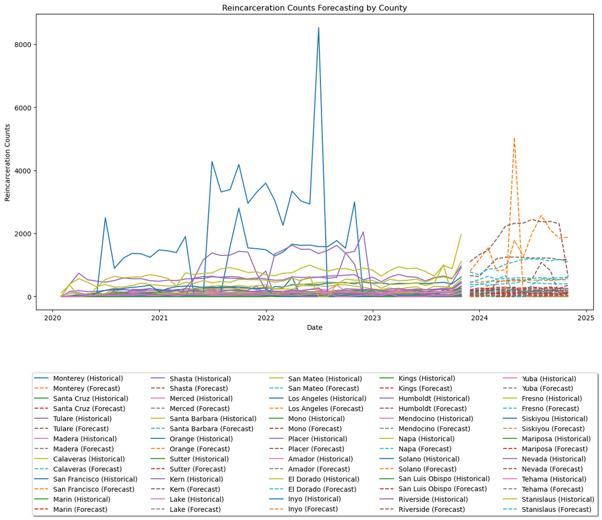

```python
import pandas as pd
from statsmodels.tsa.statespace.sarimax import SARIMAX
import matplotlib.pyplot as plt
import warnings

# Suppress specific warnings
warnings.filterwarnings("ignore", message="Too few observations to estimate starting parameters for seasonal ARMA. All parameters except for variances will be set to zeros.", category=UserWarning)
warnings.filterwarnings("ignore", message="Non-invertible starting MA parameters found. Using zeros as starting parameters.", category=UserWarning)
warnings.filterwarnings("ignore", message="Non-stationary starting autoregressive parameters found. Using zeros as starting parameters.", category=UserWarning)
# Suppress all warnings
warnings.filterwarnings("ignore")

# Assuming df_pivot is your DataFrame with counties as columns and months as rows

# Train-Test Split
train_size = int(len(df_pivot) * 0.8)
train, test = df_pivot[:train_size], df_pivot[train_size:]

# Model Training and Forecasting for each county
forecast_results = {}
for county in df_pivot.columns:
    model = SARIMAX(train[county], order=(1, 1, 1), seasonal_order=(1, 1, 1, 12))
    fit_model = model.fit( disp = False)

    # Forecasting beyond October 2023
    forecast_horizon = 12
    forecast = fit_model.get_forecast(steps=forecast_horizon)
    forecast_values = forecast.predicted_mean

    # Set negative predictions to zero
    forecast_values = forecast_values.apply(lambda x: max(x, 0))

    # Save forecast results
    forecast_results[county] = forecast_values

# Visualization
plt.figure(figsize=(15, 8))
for county in df_pivot.columns:
    plt.plot(df_pivot.index, df_pivot[county], label=county + ' (Historical)')
    plt.plot(forecast_index, forecast_results[county], linestyle='dashed', label=county + ' (Forecast)')

plt.title('Reincarceration Counts Forecasting by County')
plt.xlabel('Date')
plt.ylabel('Reincarceration Counts')
plt.legend(loc='upper center', bbox_to_anchor=(0.5, -0.2), fancybox=True, shadow=True, ncol=5)

plt.show()
```

```python
display(forecast_results)
```

```
{'Monterey': 2023-01-31      0.000000
 2023-02-28      2.510469
 2023-03-31    361.661472
 2023-04-30      0.000000
 2023-05-31      0.000000
 2023-06-30      0.000000
 2023-07-31      0.000000
 2023-08-31      0.000000
 2023-09-30      0.000000
 2023-10-31      0.000000
 2023-11-30      0.000000
 2023-12-31      0.000000
 Freq: M, Name: predicted_mean, dtype: float64,
 'Santa Cruz': 2023-01-31    175.594433
 2023-02-28    198.569267
 2023-03-31    204.644142
 2023-04-30    208.019297
 2023-05-31    205.810815
 2023-06-30    215.798019
 2023-07-31    227.745761
 2023-08-31    259.355536
 2023-09-30    256.365954
 2023-10-31    252.484751
 2023-11-30    245.578907
 2023-12-31    251.356587
 Freq: M, Name: predicted_mean, dtype: float64,
 'Tulare': 2023-01-31       0.000000
 2023-02-28       0.000000
 2023-03-31     101.591907
 2023-04-30     452.105667
 2023-05-31     509.224966
 2023-06-30     535.308798
 2023-07-31     518.959088
 2023-08-31     559.412741
 2023-09-30    1080.737964
 2023-10-31     822.656289
 2023-11-30     104.897149
 2023-12-31     111.230309
 Freq: M, Name: predicted_mean, dtype: float64,
 'Madera': 2023-01-31     93.951007
```

[output cut: 400 more lines]

```
 2023-12-31    34.955026
 Freq: M, Name: predicted_mean, dtype: float64,
 'Stanislaus': 2023-01-31    441.096746
 2023-02-28    534.502477
 2023-03-31    640.062549
 2023-04-30    538.948517
 2023-05-31    661.160573
 2023-06-30      0.000000
 2023-07-31      0.000000
 2023-08-31    385.575695
 2023-09-30    565.179278
 2023-10-31    535.881047
 2023-11-30    533.902582
 2023-12-31    529.362672
 Freq: M, Name: predicted_mean, dtype: float64}
```

### Interpretation

In attempting to construct a predictive model for next year's re-incarceration counts, a critical consideration arises regarding the choice between time series analysis and machine learning approaches. Time series models excel when the primary focus is on capturing and forecasting patterns inherent in the sequential nature of the data, such as trends, seasonality, and cyclicality. These models work most effectively when the dataset consists of individual counts for each county across various time frames, allowing for the isolation of temporal patterns specific to each jurisdiction. On the other hand, machine learning models, by their nature, can incorporate a diverse set of variables beyond time, providing a comprehensive approach to prediction. While time series models are adept at uncovering temporal intricacies, machine learning models offer the advantage of considering additional factors, such as demographics, socio-economic indicators, and other contextual variables, to build a more holistic predictive framework. The choice between these approaches depends on the specific objectives of the analysis and the nature of the available data.